# orphatools-vignette

```r
suppressWarnings(suppressPackageStartupMessages(library(orphatools)))
suppressWarnings(suppressPackageStartupMessages(library(kableExtra)))
suppressWarnings(suppressPackageStartupMessages(library(dplyr)))
```

# Orpha code properties

**Classification Levels reminder** :

- Group of disorders : 36540
- Disorder : 36547
- Subtype of disorder : 36554

```r
nom_data = load_nomenclature()
kable(head(nom_data), 'html')
```

[output not shown]

```r
nom_data = translate_properties(nom_data)
kable(head(nom_data), 'html')
```

| orphaCode | name | flagValue | disorderType | classLevel |
| --- | --- | --- | --- | --- |
| 166024 | Dysplasie épiphysaire multiple type Al-Gazali | Active | Disease | Disorder |
| 58 | Maladie d’Alexander | Active | Disease | Disorder |
| 166032 | Dysplasie épiphysaire multiple avec miniépiphyse | Active | Disease | Disorder |
| 61 | Alpha-mannosidose | Active | Disease | Disorder |
| 166029 | Dysplasie épiphysaire multiple avec dysplasie fémorale sévère | Active | Disease | Disorder |
| 166038 | Chondrodysplasie métaphysaire type Kaitila | Active | Disease | Disorder |

# Find corresponding disorder / lowest groups of disorders

```r
subtype_to_disorder(subtypeCode = '158676') # 158676 is a subtype of disorder
```

```
#> [1] "595356"
```

```r
subtype_to_disorder(subtypeCode = '303') # 303 is a group of disorder
```

```
#> character(0)
```

```r
get_lowest_groups(orphaCode = '158676')
```

```
#> [1] "303"
```

It is not recommended to use `subtype_to_disorder` on multiple ORPHAcodes because of efficiency issues. For a general “rolling up” operation, you will probably need to :

1. convert your data frame to an orpha_df object. The usage of *force_nodes* argument allows you to make appear any OPRHA code you need (like disorder codes), even if they are not present in data (but the subtypes are).
2. `group_by` and `summarize`/`mutate`.
3. Filter disorder codes.

See section below about “Counting code” for more details.

# Ancestors

## Find ancestors codes

```r
code = '303'
ancestors_codes = get_ancestors(code, codes_only=TRUE)
print(ancestors_codes)
```

```
#> [1] "93890"  "139027" "98053"  "68346"  "183426" "79361"  "183530" "89826"
#> [9] "79353"
```

## Build edgelist

```r
df_ancestors = get_ancestors(code)
kable(df_ancestors, 'html')
```

| from | to |
| --- | --- |
| 93890 | 139027 |
| 139027 | 303 |
| 98053 | 68346 |
| 98053 | 183530 |
| 68346 | 183426 |
| 183426 | 79361 |
| 79361 | 303 |
| 183530 | 139027 |
| 89826 | 79353 |
| 79353 | 79361 |

### Specify classification

**Classifications list :**

```r
all_class = load_classifications()
print(names(all_class))
```

```
#>  [1] "ORPHAclassification_146_rare_cardiac_diseases_fr"
#>  [2] "ORPHAclassification_147_rare_developmental_anomalies_during_embryogenesis_fr"
#>  [3] "ORPHAclassification_148_rare_cardiac_malformations_fr"
#>  [4] "ORPHAclassification_150_rare_inborn_errors_of_metabolism_fr"
#>  [5] "ORPHAclassification_152_rare_gastroenterological_diseases_fr"
#>  [6] "ORPHAclassification_156_rare_genetic_diseases_fr"
#>  [7] "ORPHAclassification_181_rare_neurological_diseases_fr"
#>  [8] "ORPHAclassification_182_rare_abdominal_surgical_diseases_fr"
#>  [9] "ORPHAclassification_183_rare_hepatic_diseases_fr"
#> [10] "ORPHAclassification_184_rare_respiratory_diseases_fr"
#> [11] "ORPHAclassification_185_rare_urogenital_diseases_fr"
#> [12] "ORPHAclassification_186_rare_surgical_thoracic_diseases_fr"
#> [13] "ORPHAclassification_187_rare_skin_diseases_fr"
#> [14] "ORPHAclassification_188_rare_renal_diseases_fr"
#> [15] "ORPHAclassification_189_rare_ophthalmic_diseases_fr"
```

[output cut: 18 more lines]

```r
df_ancestors = get_ancestors(code, class_data = all_class[['ORPHAclassification_156_rare_genetic_diseases_fr']])
kable(df_ancestors, 'html')
```

| from | to |
| --- | --- |
| 98053 | 68346 |
| 98053 | 183530 |
| 68346 | 183426 |
| 183426 | 79361 |
| 79361 | 303 |
| 183530 | 139027 |
| 139027 | 303 |

```r
df_ancestors = get_ancestors(code, class_data = all_class[['ORPHAclassification_146_rare_cardiac_diseases_fr']])
kable(df_ancestors, 'html')
```

# Descendants

## Find descendants codes

```r
descendants_codes = get_descendants(code, codes_only=TRUE)
print(descendants_codes)
```

```
#>  [1] "595356" "79410"  "158673" "158676" "79408"  "79409"  "79411"  "89842"
#>  [9] "89843"  "231568"
```

## Build edgelist

```r
df_descendants = get_descendants(code)
kable(df_descendants, 'html')
```

| from | to |
| --- | --- |
| 303 | 79408 |
| 303 | 79409 |
| 303 | 595356 |
| 303 | 79411 |
| 303 | 89842 |
| 303 | 89843 |
| 303 | 231568 |
| 595356 | 79410 |
| 595356 | 158673 |
| 595356 | 158676 |

### Specify classification

Specifying classification won’t change the output but will just save a small amount of time.

```r
df_descendants = get_descendants(code, class_data = all_class[['ORPHAclassification_156_rare_genetic_diseases_fr']])
kable(df_descendants, 'html')
```

| from | to |
| --- | --- |
| 303 | 79408 |
| 303 | 79409 |
| 303 | 595356 |
| 303 | 79411 |
| 303 | 89842 |
| 303 | 89843 |
| 303 | 231568 |
| 595356 | 79410 |
| 595356 | 158673 |
| 595356 | 158676 |

```r
df_descendants = get_descendants(code, class_data = all_class[['ORPHAclassification_146_rare_cardiac_diseases_fr']])
kable(df_descendants, 'html')
```

# Siblings

## Find siblings codes

```r
code = '79361'
siblings_codes = get_siblings(code)
print(siblings_codes)
```

```
#>  [1] "2841"   "79357"  "79360"  "168606" "183435" "183438" "183441" "183444"
#>  [9] "222628" "488168" "79354"  "79355"  "79356"  "79358"  "79359"  "254367"
```

## Build edgelist

```r
df_siblings = get_siblings(code)
kable(df_siblings, 'html')
```

| x |
| --- |
| 2841 |
| 79357 |
| 79360 |
| 168606 |
| 183435 |
| 183438 |
| 183441 |
| 183444 |
| 222628 |
| 488168 |
| 79354 |
| 79355 |
| 79356 |
| 79358 |
| 79359 |
| 254367 |

## Specify classification

```r
df_siblings = get_siblings(code, class_data = all_class[['ORPHAclassification_156_rare_genetic_diseases_fr']])
kable(df_siblings, 'html')
```

| x |
| --- |
| 2841 |
| 79357 |
| 79360 |
| 168606 |
| 183435 |
| 183438 |
| 183441 |
| 183444 |
| 222628 |
| 488168 |

```r
df_siblings = get_siblings(code, class_data = all_class[['ORPHAclassification_187_rare_skin_diseases_fr']])
kable(df_siblings, 'html')
```

| x |
| --- |
| 79354 |
| 79355 |
| 79356 |
| 79357 |
| 79358 |
| 79359 |
| 222628 |
| 254367 |

# Visualization

## Plots

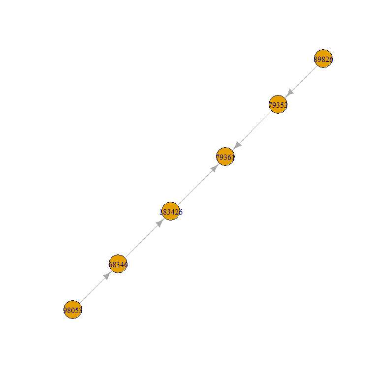

```r
df_ancestors = get_ancestors(code)
graph_ancestors = igraph::graph_from_data_frame(df_ancestors)

plot(graph_ancestors)
```

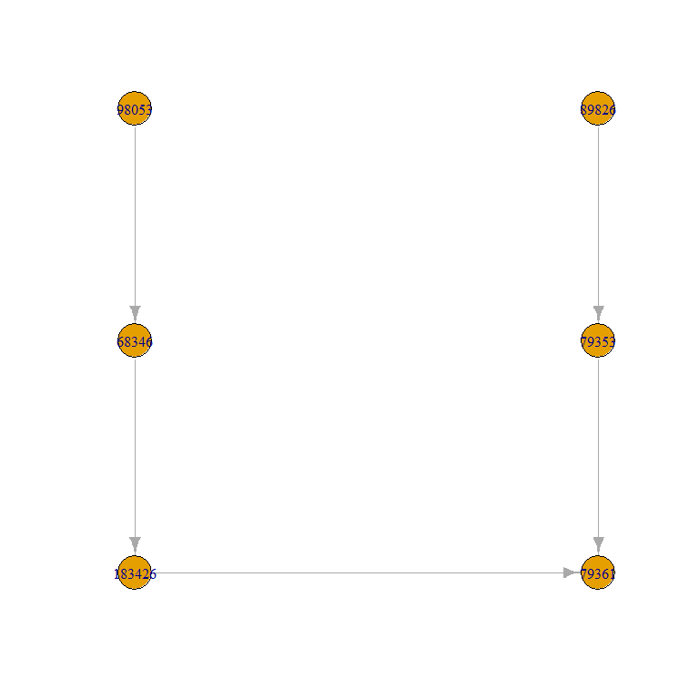

```r
plot(graph_ancestors, layout=igraph::layout_as_tree)
```

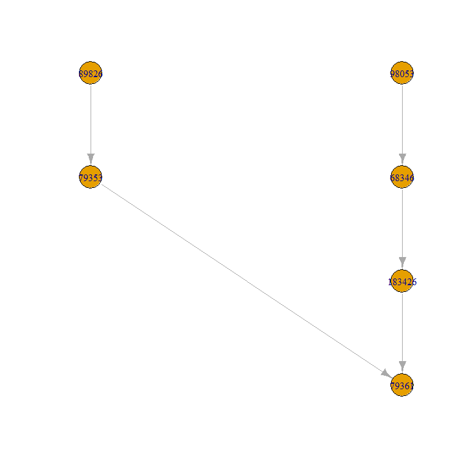

```r
plot(graph_ancestors, layout=layout_tree)
```

Try `interactive_plot` function for a dynamic plot.

## Hierarchical structures

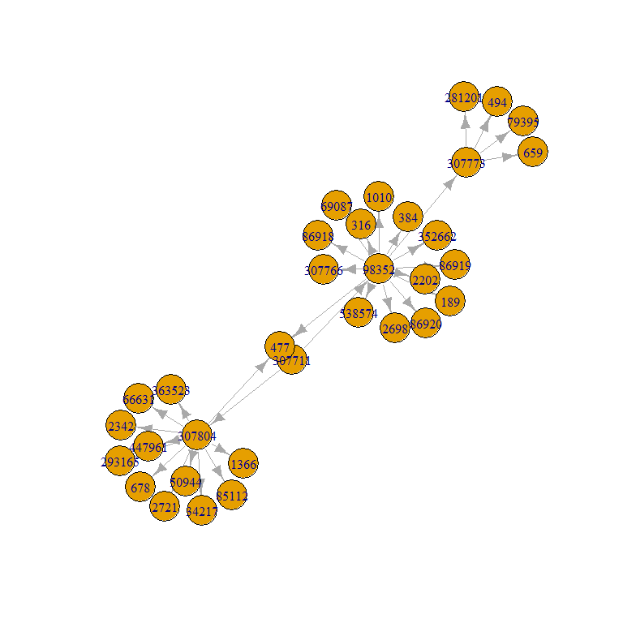

```r
df = get_descendants('307711')
graph = igraph::graph_from_data_frame(df)
plot(graph)
```

```r
df_index = assign_indent_index(df)
df_test = df_index %>% mutate(N = 1:nrow(df_index))
M_shifted = apply_indent(df_test, cols_to_display = c('code', 'N'))
kable(M_shifted, 'html')
```

| 307711 | 1 |  |  |  |
| --- | --- | --- | --- | --- |
|  | 98352 | 2 |  |  |
|  |  | 477 | 3 |  |
|  |  | 189 | 4 |  |
|  |  | 1010 | 5 |  |
|  |  | 2202 | 6 |  |
|  |  | 2698 | 7 |  |
|  |  | 316 | 8 |  |
|  |  | 384 | 9 |  |
|  |  | 69087 | 10 |  |
|  |  | 86918 | 11 |  |
|  |  | 86919 | 12 |  |
|  |  | 86920 | 13 |  |
|  |  | 307766 | 14 |  |
|  |  | 307773 | 15 |  |
|  |  |  | 494 | 16 |
|  |  |  | 659 | 17 |
|  |  |  | 79395 | 18 |
|  |  |  | 281201 | 19 |
|  |  | 352662 | 20 |  |
|  |  | 538574 | 21 |  |
|  | 307804 | 22 |  |  |
|  |  | 477 | 23 |  |
|  |  | 1366 | 24 |  |
|  |  | 2342 | 25 |  |
|  |  | 2721 | 26 |  |
|  |  | 678 | 27 |  |
|  |  | 34217 | 28 |  |
|  |  | 50944 | 29 |  |
|  |  | 85112 | 30 |  |
|  |  | 293165 | 31 |  |
|  |  | 363523 | 32 |  |
|  |  | 447961 | 33 |  |
|  |  | 66631 | 34 |  |

# Operations on multiple codes

## Common graph

The “common graph” merges the ancestors and/or descendants of each code in the list.

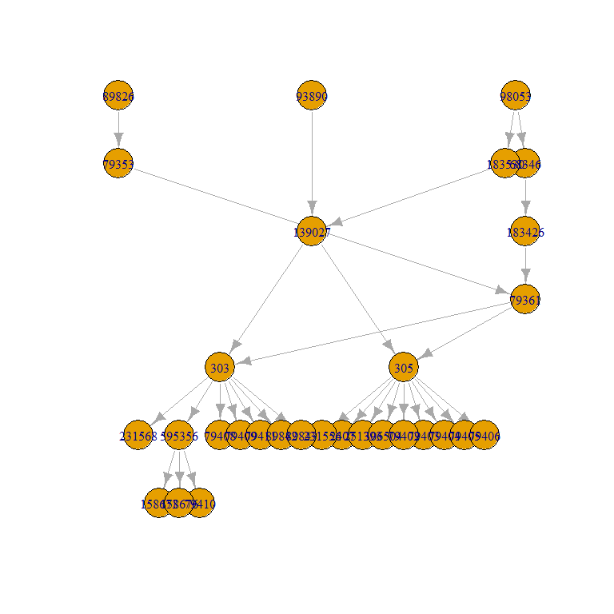

```r
codes_list = c('303', '305', '595356')
common_graph = get_common_graph(codes_list) # both
plot(common_graph, layout=layout_tree)
```

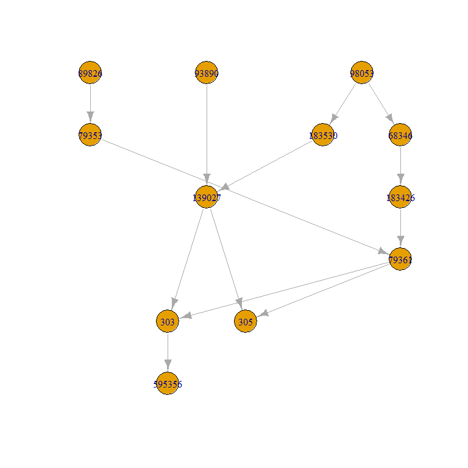

```r
common_graph = get_common_graph(codes_list, what = 'ancestors')
plot(common_graph, layout=layout_tree)
```

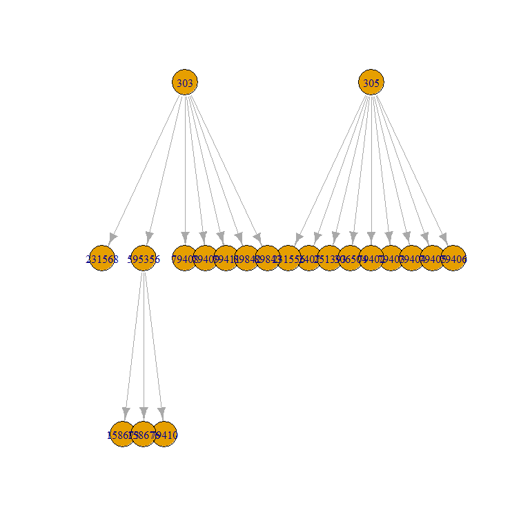

```r
common_graph = get_common_graph(codes_list, what = 'descendants')
plot(common_graph, layout=layout_tree)
```

## Color graphs

You can emphasize codes on the plotted graph to locate where are the original codes with `color_graph` function. `color_graph` enables also the visualization of the classification level (Group of disorders, Disorder, Subtype of disorder) on the plotted graph.

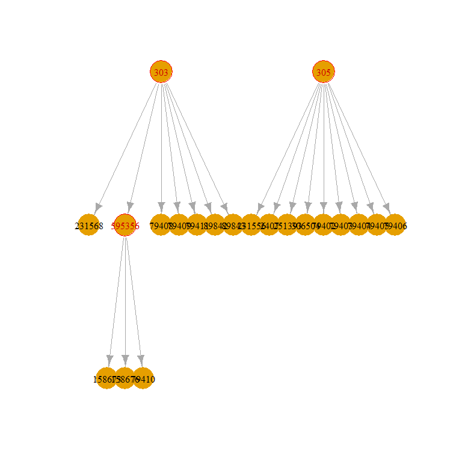

```r
colored_graph = color_graph(common_graph,
                            emphasize_nodes = codes_list,
                            display_class_levels = FALSE)
plot(colored_graph, layout=layout_tree)
```

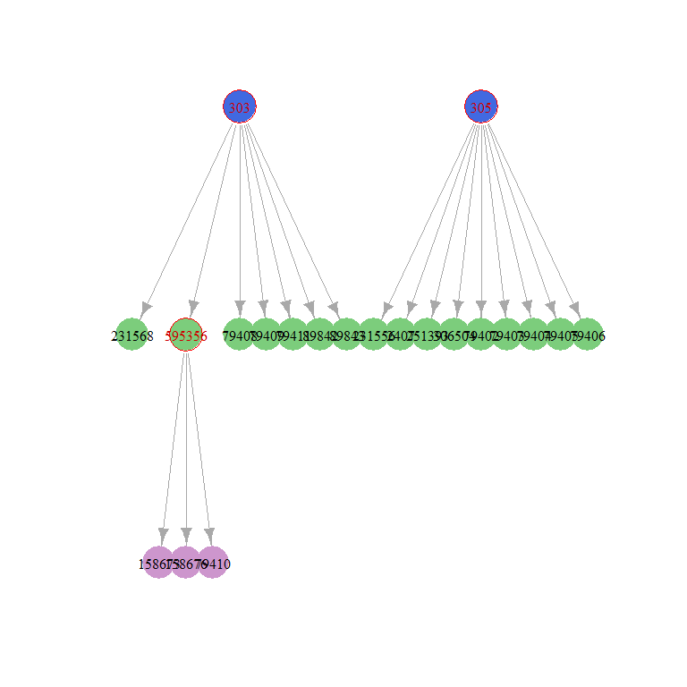

```r
colored_graph = color_graph(common_graph,
                            emphasize_nodes = codes_list)
plot(colored_graph, layout=layout_tree)
```

## Lowest Common Ancestors (LCAs)

```r
get_LCAs(codes_list)
```

```
#> [1] "139027" "79361"
```

```r
get_LCAs(codes_list, class_data = all_class[['ORPHAclassification_187_rare_skin_diseases_fr']])
```

```
#> [1] "79361"
```

## Complete families

This function is useful to find codes that might have been forgotten.

[figure not shown]

```r
new_graph = complete_family(codes_list) %>%
  color_graph(emphasize_nodes = codes_list, display_class_levels = FALSE)
plot(new_graph, layout=layout_tree)
```

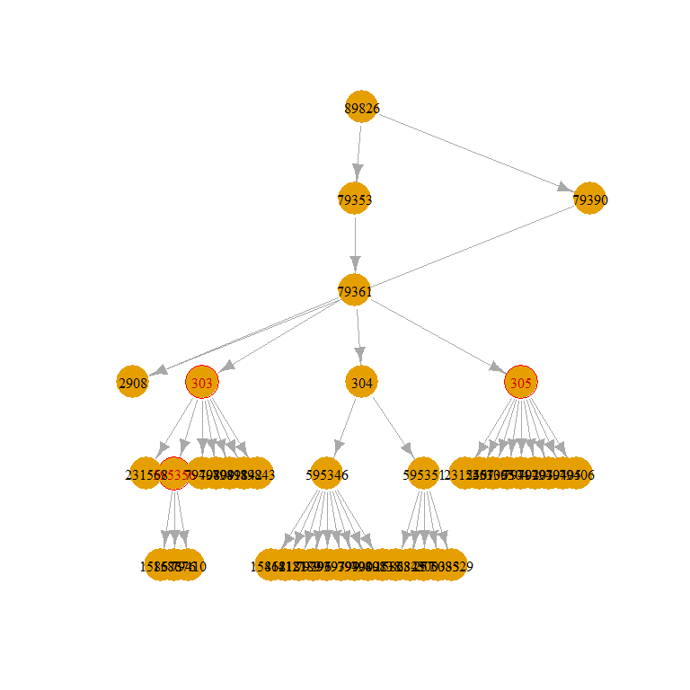

```r
# Restriction to a specific classification
new_graph = complete_family(codes_list, class_data = all_class[['ORPHAclassification_187_rare_skin_diseases_fr']]) %>%
  color_graph(emphasize_nodes = codes_list, display_class_levels = FALSE)
plot(new_graph, layout=layout_tree)
```

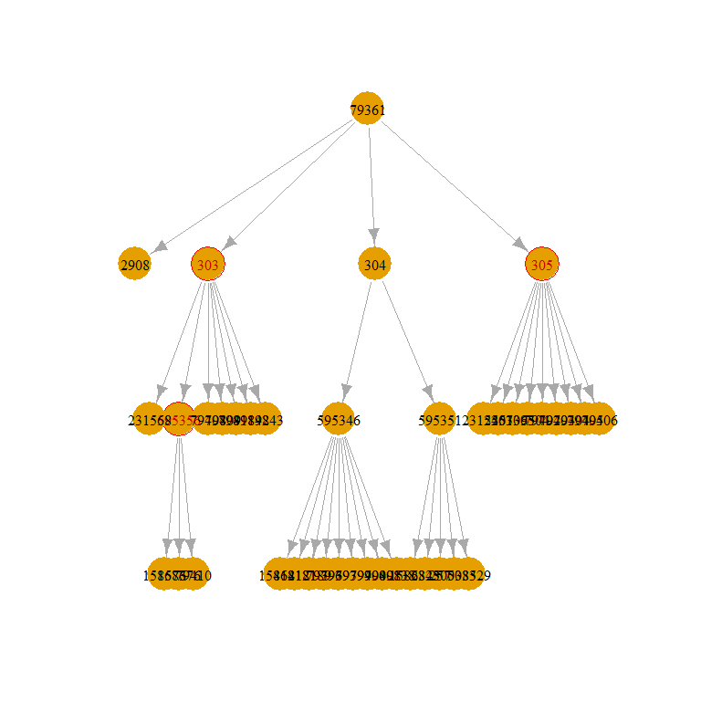

```r
# Include parents only
new_graph = complete_family(codes_list, class_data = all_class[['ORPHAclassification_187_rare_skin_diseases_fr']], include_ancestors = FALSE) %>%
  color_graph(emphasize_nodes = codes_list, display_class_levels = FALSE)
plot(new_graph, layout=layout_tree)
```

# Aggregation operations

For a hierarchical structure like the ORPHA trees, you will probably need to take codes dependencies into account. Let’s consider the simplified structure as the following :

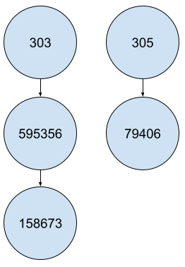

In many cases, your data operations would lead you to something like :

```r
df_patients = data.frame(patient_id = c(1,1,2,3,4,5,6),
                         code = c('303', '158673', '595356', '305', '79406', '79406', '595356'))
kable(df_patients, 'html')
```

| patient_id | code |
| --- | --- |
| 1 | 303 |
| 1 | 158673 |
| 2 | 595356 |
| 3 | 305 |
| 4 | 79406 |
| 5 | 79406 |
| 6 | 595356 |

How many patients can be gathered for each ORPHAcode ?

## Naive aggregation

The basic grouping operation will consider each ORPHAcode as independent.

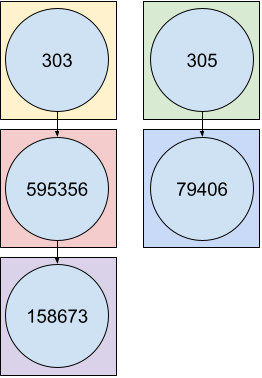

The naive counting method will then giving you the following results.

```r
df_counts = df_patients %>% group_by(code) %>% count() %>% as.data.frame()
kable(df_counts, 'html')
```

| code | n |
| --- | --- |
| 158673 | 1 |
| 303 | 1 |
| 305 | 1 |
| 595356 | 2 |
| 79406 | 2 |

## New aggregation

Converting your data frame to an `orpha_df` object will change the *group_by* behavior on data :

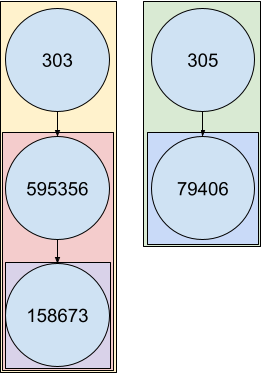

You can observe the direct effect on results of such a method :

```r
df_counts = df_patients %>% group_by_code() %>% count() %>% as.data.frame() # Deprecated
df_counts = df_patients %>% orpha_df(orphaCode_col = 'code') %>% group_by(code) %>% count() %>% as.data.frame()
kable(df_counts, 'html')
```

| code | n |
| --- | --- |
| 158673 | 1 |
| 303 | 4 |
| 305 | 3 |
| 595356 | 3 |
| 79406 | 2 |

You might also want to count distinct patients instead of all rows present in data :

```r
df_counts = df_patients %>% group_by_code() %>% summarize(n = n_distinct(patient_id)) %>% as.data.frame() # Deprecated
df_counts = df_patients %>% orpha_df(orphaCode_col = 'code') %>% group_by(code) %>% summarize(n = n_distinct(patient_id)) %>% as.data.frame()
kable(df_counts, 'html')
```

| code | n |
| --- | --- |
| 158673 | 1 |
| 303 | 3 |
| 305 | 3 |
| 595356 | 3 |
| 79406 | 2 |

This also works with `mutate`:

```r
df_ext = df_patients %>% orpha_df(orphaCode_col = 'code') %>% group_by(code) %>% mutate.grouped_orpha_df(n_included = n_distinct(patient_id)) %>% as.data.frame()
kable(df_ext, 'html')
```

| patient_id | code | n_included |
| --- | --- | --- |
| 1 | 303 | 3 |
| 1 | 158673 | 1 |
| 2 | 595356 | 3 |
| 3 | 305 | 3 |
| 4 | 79406 | 2 |
| 5 | 79406 | 2 |
| 6 | 595356 | 3 |

If your interest is focused on disorders only, keep in mind that `subtype_to_disorder` is unadvised, for computing reasons. The method presented in this section is considerably more efficient when the sample size increases. Then you simply can filter disorder codes to get the desired result.

```r
nom_data = load_nomenclature() %>% translate_properties() %>% select(orphaCode, classLevel)
df_counts = df_patients %>%
  orpha_df(orphaCode_col = 'code') %>%
  group_by(code) %>%
  summarize(n = n_distinct(patient_id)) %>%
  left_join(nom_data, by=c('code'='orphaCode')) %>%
  filter(classLevel == 'Disorder') %>%
  as.data.frame()
kable(df_counts, 'html')
```

| code | n | classLevel |
| --- | --- | --- |
| 595356 | 3 | Disorder |
| 79406 | 2 | Disorder |

```r
nom_data = load_nomenclature() %>% translate_properties() %>% select(orphaCode, classLevel)
df_counts = df_patients %>%
  orpha_df(orphaCode_col = 'code', force_nodes = 231568) %>%
  group_by(code) %>%
  summarize(n = n_distinct(patient_id)) %>%
  left_join(nom_data, by=c('code'='orphaCode')) %>%
  filter(classLevel == 'Disorder') %>%
  as.data.frame()
kable(df_counts, 'html')
```

| code | n | classLevel |
| --- | --- | --- |
| 595356 | 3 | Disorder |
| 79406 | 2 | Disorder |